**Machine Learning**

By Prof. Seungchul Lee  
http://iai.postech.ac.kr/  
Industrial AI Lab at POSTECH

Table of Contents

# 1. Introduction

## 1.1. Course Info

- Machine learning
  - Linear algebra
  - Optimization
  - Statistical and probabilistic approaches
- Python in class and assignments
  - use it a lot
  - Provide all necessary .py codes for a class

## 1.2. What is Machine Learning

- Draw a meaningful conclusion, given a set of data (observation, measurement)
- In 1959, Arthur Samuel defined [machine learning](https://en.wikipedia.org/wiki/Machine_learning) as a "Field of study that gives computers the ability to learn without being explicitly programmed"
  - Often hand programming not possible
  - Solution? Get the computer to program itself, by showing it examples of the behavior we want! This is the *learning* approach of AI
  - Really, we write the structure of the program and the computer tunes many internal parameters
- Many related terms:
  - Pattern recognition
  - Neural networks $\rightarrow$ Deep learning
  - Data mining
  - Adaptive control
  - Statistical modeling
  - Data analytics / data science
  - Artificial intelligence
  - Machine learning

(source: [lecture video](https://www.youtube.com/embed/mgBrXnjF8R4?vq=hd1080&autoplay=1) from The Machine Learning Summer School by [Zoubin Ghahramani](http://mlg.eng.cam.ac.uk/zoubin/), Univ. of Cambridge)

## 1.3. Learning: the View from Different Fields

- Engineering
  - Signal processing, system identification, adaptive and optimal control, information theory, robotics, …
- Computer science
  - Artificial intelligence, computer vision, …
- Statistics
  - Learning theory, data mining, learning and inference from data, …
- Cognitive science and psychology
  - Perception, movement control, reinforcement learning, mathematical psychology, …
- Economics
  - Decision theory, game theory, operational research, …

(source: [lecture video](https://www.youtube.com/embed/mgBrXnjF8R4?vq=hd1080&autoplay=1) from The Machine Learning Summer School by [Zoubin Ghahramani](http://mlg.eng.cam.ac.uk/zoubin/), Univ. of Cambridge)

## 1.4. Course Roadmap

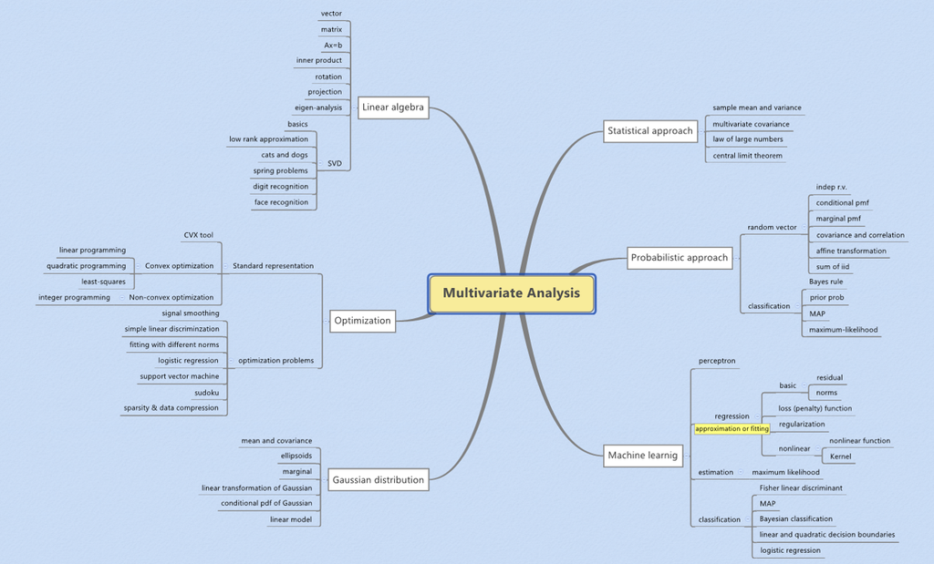

# 2. What Will We Cover?

- I will show you some examples

## 2.1. Data Fitting or Approximation (Regression)

- a statistical process for estimating the relationships among variables (source: [wikipedia](https://en.wikipedia.org/wiki/Regression_analysis))

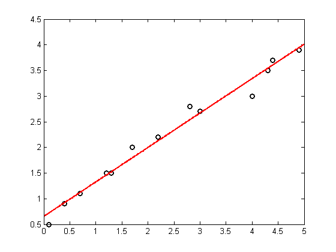

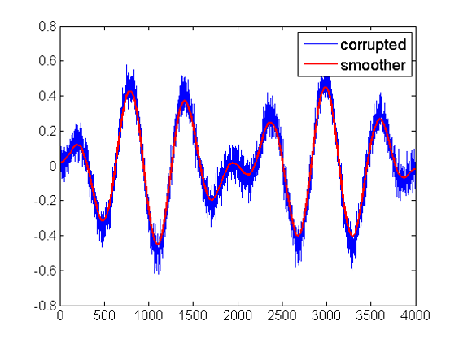

## 2.2. Classification

- the problem of identifying to which of a set of categories (sub-populations) a new observation belongs, on the basis of a training set of data containing observations (or instances) whose category membership is known (source: [wikipedia](https://en.wikipedia.org/wiki/Statistical_classification))

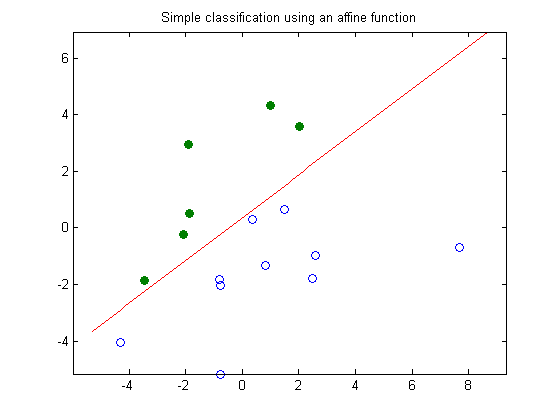

## 2.3. Gaussian Density Distribution for Probabilistic Approach

- Conditional of a joint Gaussian is Gaussian

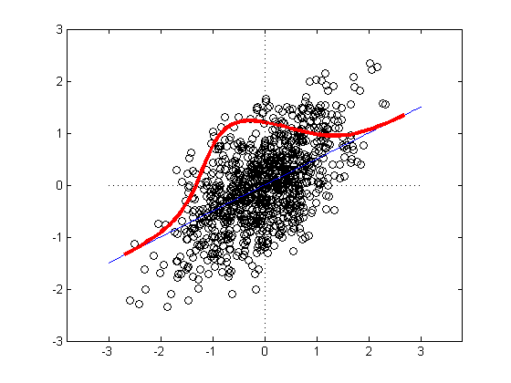

## 2.4. Machine Learning in Image Processing

- Low rank approximation
- Data compression

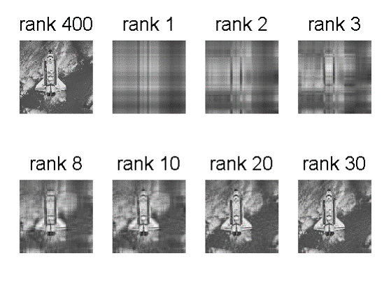

## 2.5. Handwritten Digit Recognition

- famous classification problem

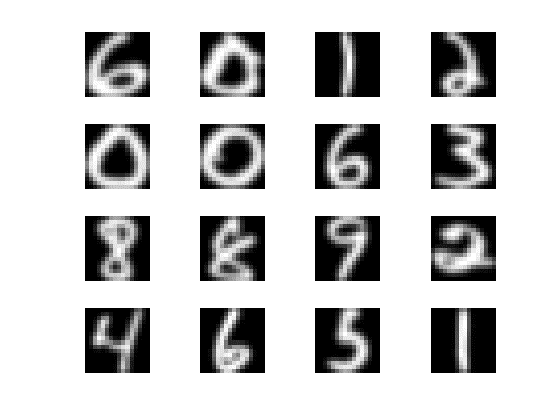

## 2.6. Face Recognition

- famous classification problem

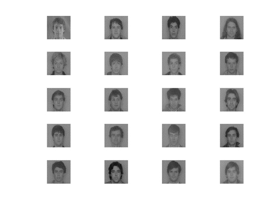

## 2.7. Dimension Reduction (Multiple Senses + Principal Components)

- the process of reducing the number of random variables under consideration, and can be divided into feature selection and feature extraction.

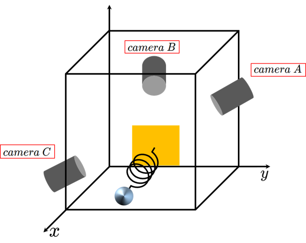

# Next Class

- Linear algebra review by Prof. Zico Kolter from CMU
- online available
  - http://www.cs.cmu.edu/~zkolter/course/linalg/
  - http://www.cs.cmu.edu/~jingx/docs/linearalgebra.pdf

```python
%%javascript
$.getScript('https://kmahelona.github.io/ipython_notebook_goodies/ipython_notebook_toc.js')
```